# Trabajo Final - Estadistica Espacial

# Limpieza de datos

En el mapa observamos que hay puntos muy distantes de la Argentina continental. Dado el proposito de este estudio, el cual es determinar la ubicacion geografica óptima en base a la variable velocidad del viento, decidimos remover estas observaciones ya que no aporta informacion util y ademas agregan ruido a nuestro analisis.

Primero, vamos a borrar las estaciones que no estan en la plataforma continental argentina - Base Carlini - Base San Martin - Base Marambio - Base Esperanza - Base Orcadas

```r
data_agg_sf = data_agg_sf[data_agg_sf$NOMBRE != "BASE CARLINI (EX JUBANY)",]
data_agg_sf = data_agg_sf[data_agg_sf$NOMBRE != "BASE SAN MARTIN",]
data_agg_sf = data_agg_sf[data_agg_sf$NOMBRE != "BASE MARAMBIO",]
data_agg_sf = data_agg_sf[data_agg_sf$NOMBRE != "BASE ESPERANZA",]
data_agg_sf = data_agg_sf[data_agg_sf$NOMBRE != "BASE ORCADAS",]
data_agg_sf = data_agg_sf[data_agg_sf$NOMBRE != "BASE BELGRANO II",]
```

Luego, observamos que la estacion de El Bolson tiene las 9 observaciones en 0 para la variable FF y DD. Consideramos esto como un error en el instrumento de medicion, por lo cual vamos a eliminar a esa estacion del analisis.

```r
data_agg_sf = data_agg_sf[data_agg_sf$NOMBRE != "EL BOLSON AERO",]
```

Repetimos el plot para validar

```r
labs <- lapply(seq(nrow(data_agg_sf)), function(i) {
  paste0( '<p>', data_agg_sf[i, "NOMBRE"], '</p>' ) })


leaflet() %>%
  addTiles() %>%
  addCircles(data = data_agg_sf, weight = 3, label = lapply(labs, htmltools::HTML))
```

[interactive chart not shown]

```r
NA
```

Observemos el resumen estadistico de las nuevas variables MEAN_VIENTO_KMH y SD_VIENTO_KMH

```r
describe(data_agg_sf$MEAN_VIENTO_KMH)
```

|  | vars | n | mean | sd | median | trimmed | mad | min | max | range | skew | kurtosis | se |
| --- | --- | --- | --- | --- | --- | --- | --- | --- | --- | --- | --- | --- | --- |
| X1 | 1 | 91 | 16.54 | 8.42 | 15.83 | 16.02 | 8.65 | 1.1 | 46.29 | 45.19 | 0.65 | 0.61 | 0.88 |

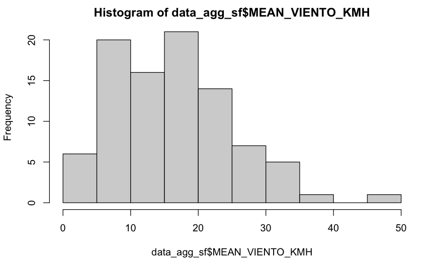

```r
hist(data_agg_sf$MEAN_VIENTO_KMH)
```

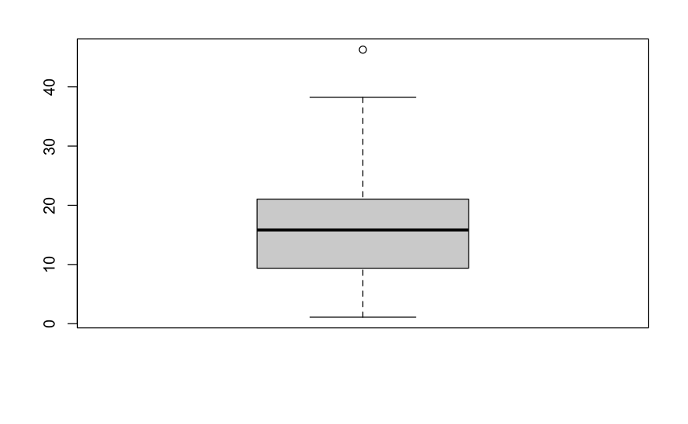

```r
boxplot(data_agg_sf$MEAN_VIENTO_KMH)
```

```r
describe(data_agg_sf$SD_VIENTO_KMH)
```

|  | vars | n | mean | sd | median | trimmed | mad | min | max | range | skew | kurtosis | se |
| --- | --- | --- | --- | --- | --- | --- | --- | --- | --- | --- | --- | --- | --- |
| X1 | 1 | 91 | 6.18 | 2.49 | 5.64 | 5.85 | 1.88 | 2.15 | 16.54 | 14.39 | 1.62 | 3.78 | 0.26 |

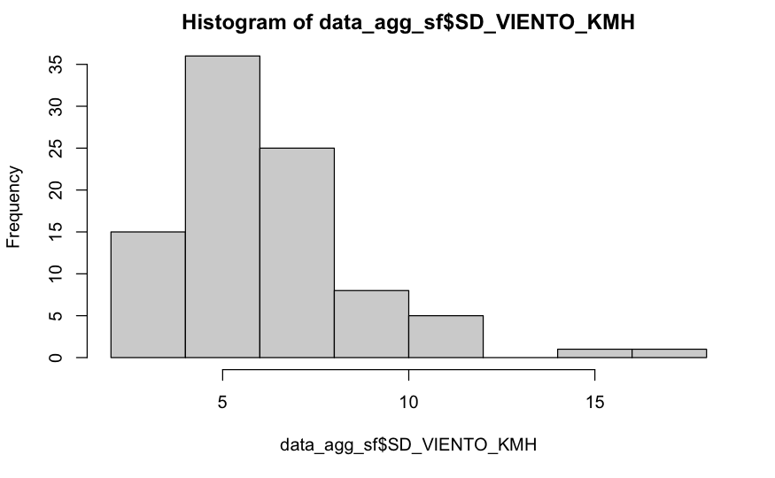

```r
hist(data_agg_sf$SD_VIENTO_KMH)
```

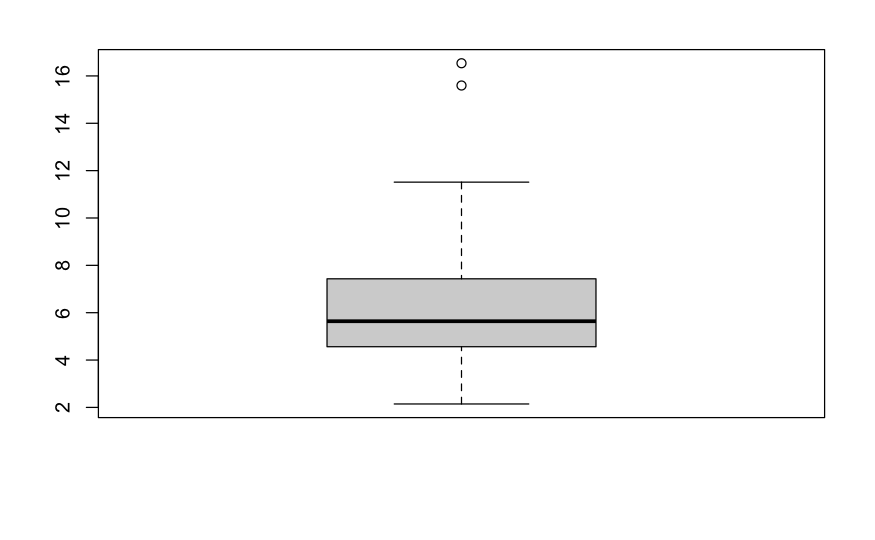

```r
boxplot(data_agg_sf$SD_VIENTO_KMH)
```

Veamos si esta nueva variable MEAN_VIENTO_KMH es normal.

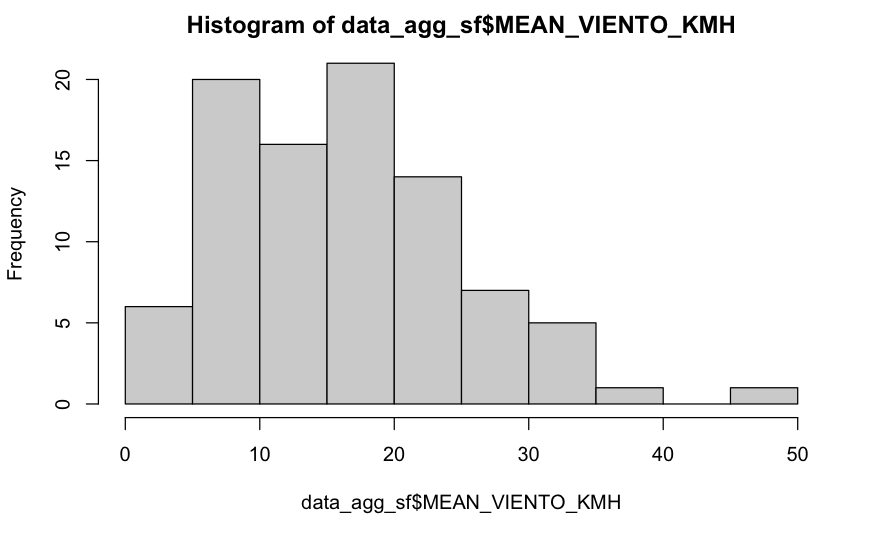

```r
hist(data_agg_sf$MEAN_VIENTO_KMH)
```

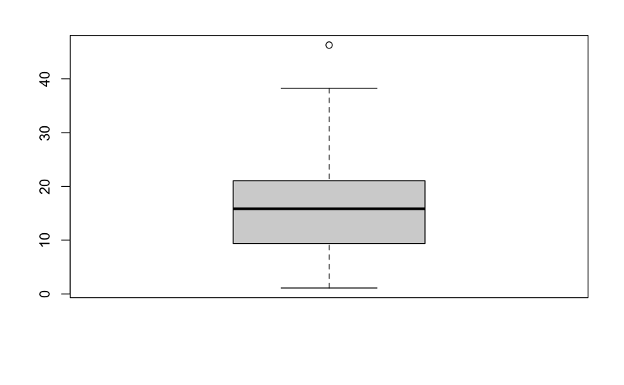

```r
boxplot(data_agg_sf$MEAN_VIENTO_KMH)
```

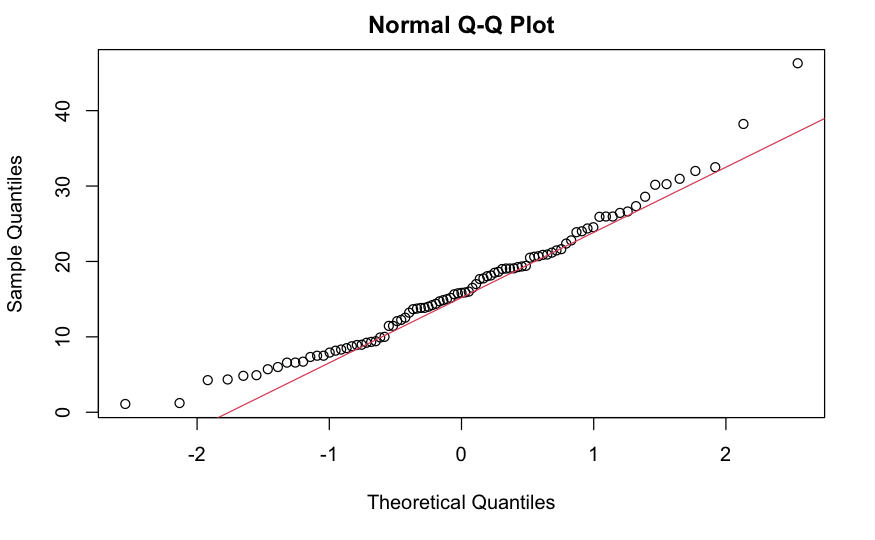

```r
qqnorm(data_agg_sf$MEAN_VIENTO_KMH)
qqline(data_agg_sf$MEAN_VIENTO_KMH, col=2)
```

```r
shapiro.test(data_agg_sf$MEAN_VIENTO_KMH)
```

```
    Shapiro-Wilk normality test

data:  data_agg_sf$MEAN_VIENTO_KMH
W = 0.9698, p-value = 0.03265
```

Ahora, procedemos a analizar la existencia de inliers, y en el caso de encontrarlos, eliminarlos.Para eso, usamos el test de moran. Basicamente lo que estamos testeando es que el promedio del viento este dristribuido de manera aleatoria siguiendo un proceso aleatorio.

```r
knea <- knearneigh(data_agg_sf)
neib <- knn2nb(knea)

listw <- nb2listw(neib)

moran_test <- moran.test(data_agg_sf$MEAN_VIENTO_KMH, listw)
moran_test
```

```
    Moran I test under randomisation

data:  data_agg_sf$MEAN_VIENTO_KMH
weights: listw

Moran I statistic standard deviate = 4.0432, p-value = 2.636e-05
alternative hypothesis: greater
sample estimates:
Moran I statistic       Expectation          Variance
       0.52033029       -0.01111111        0.01727672
```

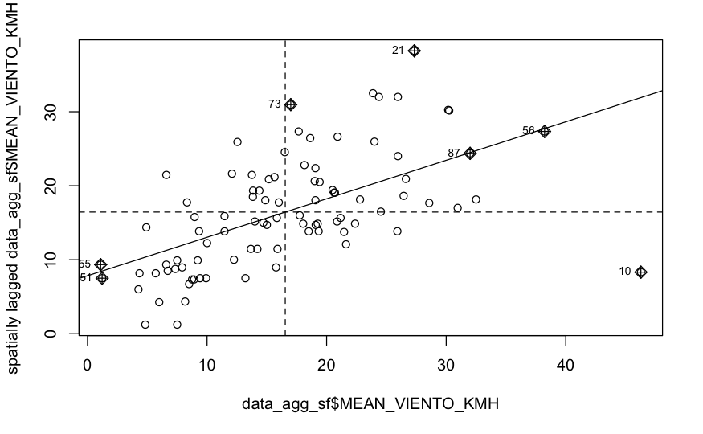

```r
moran <- moran.plot(data_agg_sf$MEAN_VIENTO_KMH, listw = listw)
```

```r
data_agg_sf[10,]
```

```
Simple feature collection with 1 feature and 3 fields
Geometry type: POINT
Dimension:     XY
Bounding box:  xmin: -65.76667 ymin: -28.6 xmax: -65.76667 ymax: -28.6
Geodetic CRS:  WGS 84
           NOMBRE MEAN_VIENTO_KMH SD_VIENTO_KMH                geometry
16 CATAMARCA AERO        46.28571      11.51397 POINT (-65.76667 -28.6)
```

```r
data_agg_sf[56,]
```

```
Simple feature collection with 1 feature and 3 fields
Geometry type: POINT
Dimension:     XY
Bounding box:  xmin: -62.38333 ymin: -37.6 xmax: -62.38333 ymax: -37.6
Geodetic CRS:  WGS 84
       NOMBRE MEAN_VIENTO_KMH SD_VIENTO_KMH                geometry
63 PIGUE AERO        38.23077      6.905962 POINT (-62.38333 -37.6)
```

```r
data_agg_sf[87,]
```

```
Simple feature collection with 1 feature and 3 fields
Geometry type: POINT
Dimension:     XY
Bounding box:  xmin: -61.96667 ymin: -33.66667 xmax: -61.96667 ymax: -33.66667
Geodetic CRS:  WGS 84
               NOMBRE MEAN_VIENTO_KMH SD_VIENTO_KMH                    geometry
94 VENADO TUERTO AERO              32      11.09955 POINT (-61.96667 -33.66667)
```

```r
data_agg_sf[21,]
```

```
Simple feature collection with 1 feature and 3 fields
Geometry type: POINT
Dimension:     XY
Bounding box:  xmin: -61.88333 ymin: -37.43333 xmax: -61.88333 ymax: -37.43333
Geodetic CRS:  WGS 84
                NOMBRE MEAN_VIENTO_KMH SD_VIENTO_KMH                    geometry
27 CORONEL SUAREZ AERO        27.33333      5.278889 POINT (-61.88333 -37.43333)
```

```r
data_agg_sf[73,]
```

```
Simple feature collection with 1 feature and 3 fields
Geometry type: POINT
Dimension:     XY
Bounding box:  xmin: -66.35 ymin: -33.26667 xmax: -66.35 ymax: -33.26667
Geodetic CRS:  WGS 84
          NOMBRE MEAN_VIENTO_KMH SD_VIENTO_KMH                 geometry
80 SAN LUIS AERO              17      7.901568 POINT (-66.35 -33.26667)
```

```r
data_agg_sf[51,]
```

```
Simple feature collection with 1 feature and 3 fields
Geometry type: POINT
Dimension:     XY
Bounding box:  xmin: -64.31667 ymin: -23.15 xmax: -64.31667 ymax: -23.15
Geodetic CRS:  WGS 84
      NOMBRE MEAN_VIENTO_KMH SD_VIENTO_KMH                 geometry
58 ORAN AERO        1.222222      2.981424 POINT (-64.31667 -23.15)
```

```r
data_agg_sf[55,]
```

```
Simple feature collection with 1 feature and 3 fields
Geometry type: POINT
Dimension:     XY
Bounding box:  xmin: -71.01667 ymin: -46.51667 xmax: -71.01667 ymax: -46.51667
Geodetic CRS:  WGS 84
               NOMBRE MEAN_VIENTO_KMH SD_VIENTO_KMH                    geometry
62 PERITO MORENO AERO             1.1      3.478505 POINT (-71.01667 -46.51667)
```

```r
data_agg_sf = data_agg_sf[data_agg_sf$NOMBRE != "CERES AERO",]
data_agg_sf = data_agg_sf[data_agg_sf$NOMBRE != "SAN LUIS AERO",]
data_agg_sf = data_agg_sf[data_agg_sf$NOMBRE != "PERITO MORENO AERO",]
data_agg_sf = data_agg_sf[data_agg_sf$NOMBRE != "ORAN AERO",]
data_agg_sf = data_agg_sf[data_agg_sf$NOMBRE != "CORONEL SUAREZ AERO",]
data_agg_sf = data_agg_sf[data_agg_sf$NOMBRE != "PIGUE AERO",]
data_agg_sf = data_agg_sf[data_agg_sf$NOMBRE != "CATAMARCA AERO",]
```

# Inliers: verificamos los resultados dsp de eliminar inliers

```r
# Creamos una lista de vecinos
knea <- knearneigh(data_agg_sf)
neib <- knn2nb(knea)
listw <- nb2listw(neib)

# Hacemos el test de moran
globalMoran <- moran.test(data_agg_sf$MEAN_VIENTO_KMH, listw)
globalMoran
```

```
    Moran I test under randomisation

data:  data_agg_sf$MEAN_VIENTO_KMH
weights: listw

Moran I statistic standard deviate = 4.8984, p-value = 4.83e-07
alternative hypothesis: greater
sample estimates:
Moran I statistic       Expectation          Variance
       0.66907198       -0.01204819        0.01933449
```

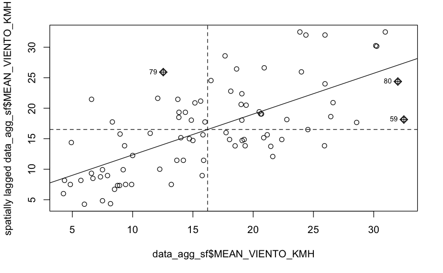

```r
moran <- moran.plot(data_agg_sf$MEAN_VIENTO_KMH, listw = listw)
```

```r
data_agg_sf[81,]
```

```
Simple feature collection with 1 feature and 3 fields
Geometry type: POINT
Dimension:     XY
Bounding box:  xmin: -63.01667 ymin: -40.85 xmax: -63.01667 ymax: -40.85
Geodetic CRS:  WGS 84
        NOMBRE MEAN_VIENTO_KMH SD_VIENTO_KMH                 geometry
95 VIEDMA AERO            16.5      5.890302 POINT (-63.01667 -40.85)
```

```r
data_agg_sf[60,]
```

```
Simple feature collection with 1 feature and 3 fields
Geometry type: POINT
Dimension:     XY
Bounding box:  xmin: -69.28333 ymin: -51.61667 xmax: -69.28333 ymax: -51.61667
Geodetic CRS:  WGS 84
              NOMBRE MEAN_VIENTO_KMH SD_VIENTO_KMH                    geometry
73 RIO GALLEGOS AERO        25.91667      6.907944 POINT (-69.28333 -51.61667)
```

```r
data_agg_sf[80,]
```

```
Simple feature collection with 1 feature and 3 fields
Geometry type: POINT
Dimension:     XY
Bounding box:  xmin: -61.96667 ymin: -33.66667 xmax: -61.96667 ymax: -33.66667
Geodetic CRS:  WGS 84
               NOMBRE MEAN_VIENTO_KMH SD_VIENTO_KMH                    geometry
94 VENADO TUERTO AERO              32      11.09955 POINT (-61.96667 -33.66667)
```

```r
data_agg_sf[19,]
```

```
Simple feature collection with 1 feature and 3 fields
Geometry type: POINT
Dimension:     XY
Bounding box:  xmin: -58.76667 ymin: -27.45 xmax: -58.76667 ymax: -27.45
Geodetic CRS:  WGS 84
            NOMBRE MEAN_VIENTO_KMH SD_VIENTO_KMH                 geometry
28 CORRIENTES AERO        9.916667      5.115336 POINT (-58.76667 -27.45)
```

```r
shapiro.test(data_agg_sf$MEAN_VIENTO_KMH)
```

```
    Shapiro-Wilk normality test

data:  data_agg_sf$MEAN_VIENTO_KMH
W = 0.96946, p-value = 0.04325
```

```r
data_agg_sf = data_agg_sf[data_agg_sf$NOMBRE != "VIEDMA AERO",]
data_agg_sf = data_agg_sf[data_agg_sf$NOMBRE != "RIO GALLEGOS AERO",]
data_agg_sf = data_agg_sf[data_agg_sf$NOMBRE != "VENADO TUERTO AERO",]
data_agg_sf = data_agg_sf[data_agg_sf$NOMBRE != "CORRIENTES AERO",]
```

```r
# Creamos una lista de vecinos
knea <- knearneigh(data_agg_sf)
neib <- knn2nb(knea)
listw <- nb2listw(neib)

# Hacemos el test de moran
globalMoran <- moran.test(data_agg_sf$MEAN_VIENTO_KMH, listw)
globalMoran
```

```
    Moran I test under randomisation

data:  data_agg_sf$MEAN_VIENTO_KMH
weights: listw

Moran I statistic standard deviate = 4.8722, p-value = 5.518e-07
alternative hypothesis: greater
sample estimates:
Moran I statistic       Expectation          Variance
       0.67737208       -0.01265823        0.02005783
```

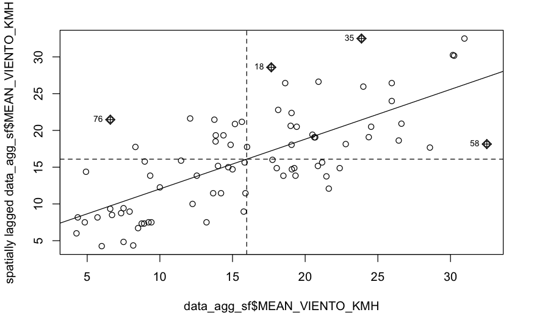

```r
moran <- moran.plot(data_agg_sf$MEAN_VIENTO_KMH, listw = listw)
```

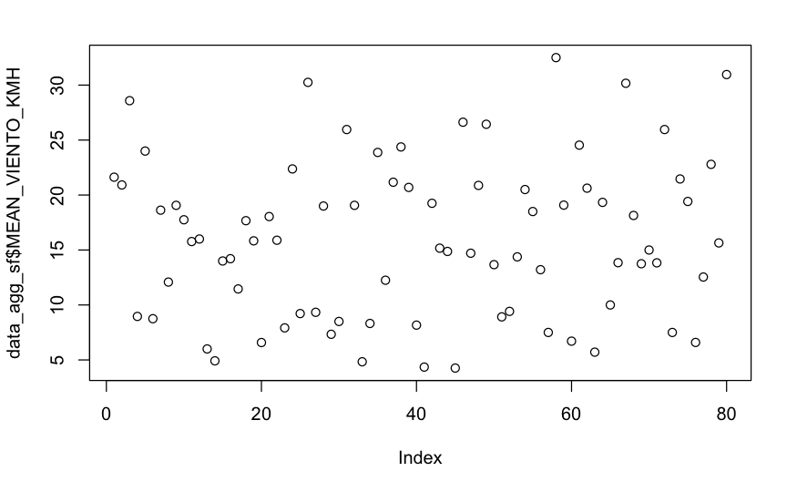

```r
plot(data_agg_sf$MEAN_VIENTO_KMH)
```

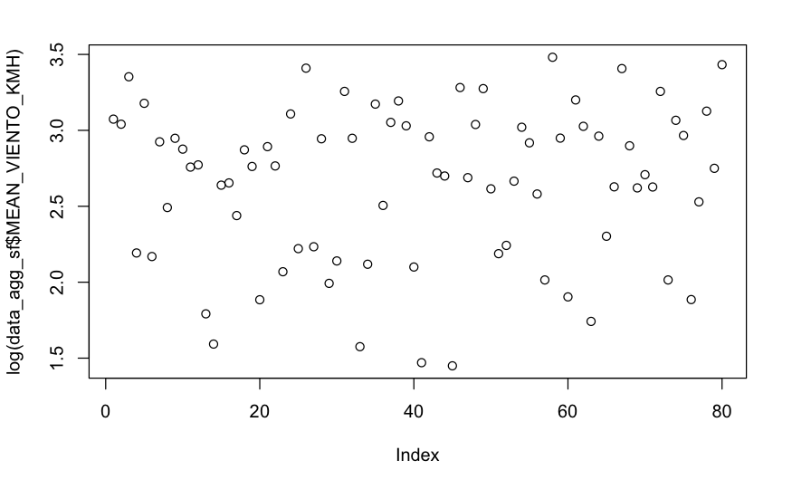

```r
plot(log(data_agg_sf$MEAN_VIENTO_KMH))
```

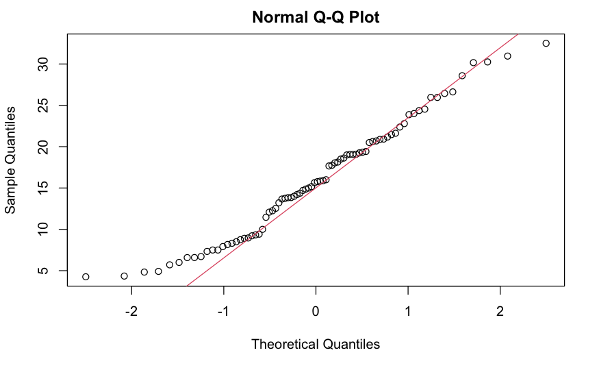

```r
qqnorm(data_agg_sf$MEAN_VIENTO_KMH)
qqline(data_agg_sf$MEAN_VIENTO_KMH, col=2)
```

```r
shapiro.test(data_agg_sf$MEAN_VIENTO_KMH)
```

```
    Shapiro-Wilk normality test

data:  data_agg_sf$MEAN_VIENTO_KMH
W = 0.97049, p-value = 0.06096
```